# Part I - Prosper Loan Dataset Exploration

## Introduction

The Prosper dataset contains information about loans originated through the Prosper peer-to-peer lending platform. The dataset includes detailed loan information such as loan terms, interest rates, borrower credit information, income details, and loan status. It consists of 113,937 observations and 81 variables.

## Preliminary Wrangling

```python
# import all packages and set plots to be embedded inline
import numpy as np
import pandas as pd
import matplotlib.pyplot as plt
import seaborn as sns
```

```python
df = pd.read_csv("prosperLoanData.csv")
df.head(5)
```

|  | ListingKey | ListingNumber | ListingCreationDate | CreditGrade | Term | LoanStatus | ClosedDate | BorrowerAPR | BorrowerRate | LenderYield | ... | LP_ServiceFees | LP_CollectionFees | LP_GrossPrincipalLoss | LP_NetPrincipalLoss | LP_NonPrincipalRecoverypayments | PercentFunded | Recommendations | InvestmentFromFriendsCount | InvestmentFromFriendsAmount | Investors |
| --- | --- | --- | --- | --- | --- | --- | --- | --- | --- | --- | --- | --- | --- | --- | --- | --- | --- | --- | --- | --- | --- |
| 0 | 1021339766868145413AB3B | 193129 | 2007-08-26 19:09:29.263000000 | C | 36 | Completed | 2009-08-14 00:00:00 | 0.16516 | 0.1580 | 0.1380 | ... | -133.18 | 0.0 | 0.0 | 0.0 | 0.0 | 1.0 | 0 | 0 | 0.0 | 258 |
| 1 | 10273602499503308B223C1 | 1209647 | 2014-02-27 08:28:07.900000000 | NaN | 36 | Current | NaN | 0.12016 | 0.0920 | 0.0820 | ... | 0.00 | 0.0 | 0.0 | 0.0 | 0.0 | 1.0 | 0 | 0 | 0.0 | 1 |
| 2 | 0EE9337825851032864889A | 81716 | 2007-01-05 15:00:47.090000000 | HR | 36 | Completed | 2009-12-17 00:00:00 | 0.28269 | 0.2750 | 0.2400 | ... | -24.20 | 0.0 | 0.0 | 0.0 | 0.0 | 1.0 | 0 | 0 | 0.0 | 41 |
| 3 | 0EF5356002482715299901A | 658116 | 2012-10-22 11:02:35.010000000 | NaN | 36 | Current | NaN | 0.12528 | 0.0974 | 0.0874 | ... | -108.01 | 0.0 | 0.0 | 0.0 | 0.0 | 1.0 | 0 | 0 | 0.0 | 158 |
| 4 | 0F023589499656230C5E3E2 | 909464 | 2013-09-14 18:38:39.097000000 | NaN | 36 | Current | NaN | 0.24614 | 0.2085 | 0.1985 | ... | -60.27 | 0.0 | 0.0 | 0.0 | 0.0 | 1.0 | 0 | 0 | 0.0 | 20 |

5 rows × 81 columns

```python
df.shape
```

```
(113937, 81)
```

```python
df.info()
```

```
<class 'pandas.core.frame.DataFrame'>
RangeIndex: 113937 entries, 0 to 113936
Data columns (total 81 columns):
 #   Column                               Non-Null Count   Dtype
---  ------                               --------------   -----
 0   ListingKey                           113937 non-null  object
 1   ListingNumber                        113937 non-null  int64
 2   ListingCreationDate                  113937 non-null  object
 3   CreditGrade                          28953 non-null   object
 4   Term                                 113937 non-null  int64
 5   LoanStatus                           113937 non-null  object
 6   ClosedDate                           55089 non-null   object
 7   BorrowerAPR                          113912 non-null  float64
 8   BorrowerRate                         113937 non-null  float64
 9   LenderYield                          113937 non-null  float64
```

[output cut: 73 more lines]

### Data cleaning

#### check missing values

```python
df.isnull().sum().sort_values(ascending=False)
```

```
GroupKey                         100596
LoanFirstDefaultedCycleNumber     96985
ScorexChangeAtTimeOfListing       95009
ProsperPrincipalOutstanding       91852
ProsperPrincipalBorrowed          91852
                                  ...
IncomeRange                           0
IncomeVerifiable                      0
StatedMonthlyIncome                   0
LoanKey                               0
Investors                             0
Length: 81, dtype: int64
```

#### Create a new dataframe with relevant columns only

```python
features = ['BorrowerAPR', 'ProsperRating (Alpha)', 'ProsperScore', 'IncomeRange',
            'StatedMonthlyIncome', 'LoanOriginalAmount', 'Term', 'LoanStatus',
            'EmploymentStatus', 'DebtToIncomeRatio', 'CreditScoreRangeLower',
            'CreditScoreRangeUpper', 'IsBorrowerHomeowner']

df_clean = df[features].copy()
```

```python
df_clean.head()
```

|  | BorrowerAPR | ProsperRating (Alpha) | ProsperScore | IncomeRange | StatedMonthlyIncome | LoanOriginalAmount | Term | LoanStatus | EmploymentStatus | DebtToIncomeRatio | CreditScoreRangeLower | CreditScoreRangeUpper | IsBorrowerHomeowner |
| --- | --- | --- | --- | --- | --- | --- | --- | --- | --- | --- | --- | --- | --- |
| 0 | 0.16516 | NaN | NaN | $25,000-49,999 | 3083.333333 | 9425 | 36 | Completed | Self-employed | 0.17 | 640.0 | 659.0 | True |
| 1 | 0.12016 | A | 7.0 | $50,000-74,999 | 6125.000000 | 10000 | 36 | Current | Employed | 0.18 | 680.0 | 699.0 | False |
| 2 | 0.28269 | NaN | NaN | Not displayed | 2083.333333 | 3001 | 36 | Completed | Not available | 0.06 | 480.0 | 499.0 | False |
| 3 | 0.12528 | A | 9.0 | $25,000-49,999 | 2875.000000 | 10000 | 36 | Current | Employed | 0.15 | 800.0 | 819.0 | True |
| 4 | 0.24614 | D | 4.0 | $100,000+ | 9583.333333 | 15000 | 36 | Current | Employed | 0.26 | 680.0 | 699.0 | True |

```python
df_clean.isnull().sum().sort_values(ascending=False)
```

```
ProsperRating (Alpha)    29084
ProsperScore             29084
DebtToIncomeRatio         8554
EmploymentStatus          2255
CreditScoreRangeLower      591
CreditScoreRangeUpper      591
BorrowerAPR                 25
IncomeRange                  0
StatedMonthlyIncome          0
LoanOriginalAmount           0
Term                         0
LoanStatus                   0
IsBorrowerHomeowner          0
dtype: int64
```

### Drop rows with missing values

```python
df_clean.dropna(inplace=True)
```

```python
df_clean.to_csv('clean_prosperLoanData.csv', index=False)
```

```python
df_clean.info()
```

```
<class 'pandas.core.frame.DataFrame'>
Index: 77557 entries, 1 to 113936
Data columns (total 13 columns):
 #   Column                 Non-Null Count  Dtype
---  ------                 --------------  -----
 0   BorrowerAPR            77557 non-null  float64
 1   ProsperRating (Alpha)  77557 non-null  object
 2   ProsperScore           77557 non-null  float64
 3   IncomeRange            77557 non-null  object
 4   StatedMonthlyIncome    77557 non-null  float64
 5   LoanOriginalAmount     77557 non-null  int64
 6   Term                   77557 non-null  int64
 7   LoanStatus             77557 non-null  object
 8   EmploymentStatus       77557 non-null  object
 9   DebtToIncomeRatio      77557 non-null  float64
 10  CreditScoreRangeLower  77557 non-null  float64
 11  CreditScoreRangeUpper  77557 non-null  float64
 12  IsBorrowerHomeowner    77557 non-null  bool
dtypes: bool(1), float64(6), int64(2), object(4)
memory usage: 7.8+ MB
```

### What is the structure of your dataset?

- The cleaned dataset contains 77,557 rows and 13 columns.
- It includes numeric, categorical, and boolean data types.
- Key columns retained are related to loan details and borrower information, such as BorrowerAPR, ProsperRating (Alpha), ProsperScore, IncomeRange, StatedMonthlyIncome, LoanOriginalAmount, Term, LoanStatus, EmploymentStatus, DebtToIncomeRatio, CreditScoreRangeLower, CreditScoreRangeUpper, and IsBorrowerHomeowner.
- All rows with missing values in these columns were dropped to ensure clean and complete data for analysis.

### What is/are the main feature(s) of interest in your dataset?

1. The main feature of interest is BorrowerAPR, which represents the annual percentage rate assigned to a borrower. I want to explore what factors contribute to a higher or lower APR.
2. LoanStatus : to understand the risk associated with loans.
3. ProsperRating : to evaluate how credit ratings influence loan terms.

### What features in the dataset do you think will help support your investigation into your feature(s) of interest?

ProsperRating (Alpha) and ProsperScore (borrower risk)

IncomeRange and StatedMonthlyIncome (financial capacity)

EmploymentStatus (employment stability)

DebtToIncomeRatio (debt burden)

CreditScoreRangeLower and CreditScoreRangeUpper (creditworthiness)

LoanOriginalAmount and Term (loan characteristics)

IsBorrowerHomeowner (financial reliability)

## Univariate Exploration

```python
sns.set(style="whitegrid") #for nicer visuals
```

### BorrowerAPR-Histogram : What is the distribution of Borrower APR (interest rate)?

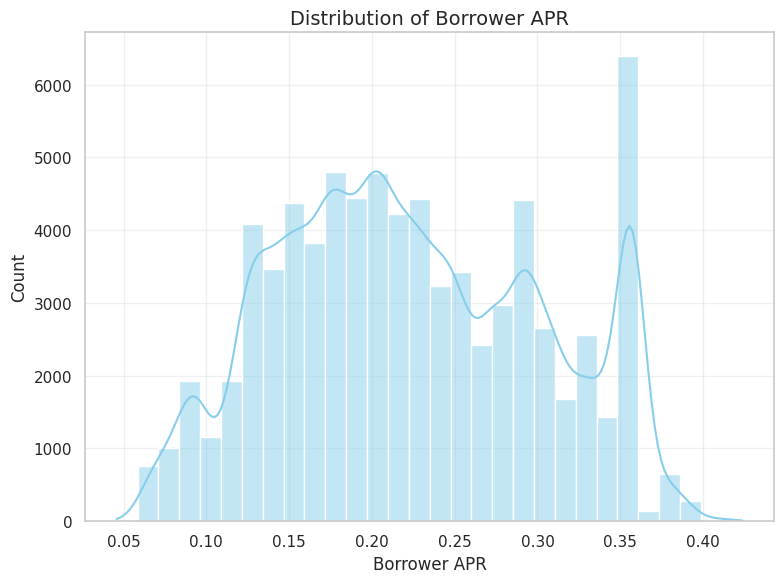

```python
plt.figure(figsize=(8, 6), facecolor='white')
sns.set_style("whitegrid")  # خلفية بيضاء مع خطوط خفيفة
sns.histplot(df_clean['BorrowerAPR'], bins=30, kde=True, color='skyblue')

plt.title('Distribution of Borrower APR', fontsize=14)
plt.xlabel('Borrower APR', fontsize=12)
plt.ylabel('Count', fontsize=12)
plt.grid(True, alpha=0.3)
plt.tight_layout()
plt.show()
```

### IncomeRange - Count Plot : What is the distribution of income ranges in the dataset?

```python
unique_ranges = df_clean['IncomeRange'].dropna().unique()

def income_sort_key(val):
    if val == 'Not employed':
        return 0
    elif val == '$0':
        return 1
    elif '-' in val:
        return int(val.replace('$', '').replace(',', '').split('-')[0])
    elif '$100,000+' in val:
        return 100000
    elif 'Not displayed' in val:
        return float('inf')
    else:
        return np.nan
```

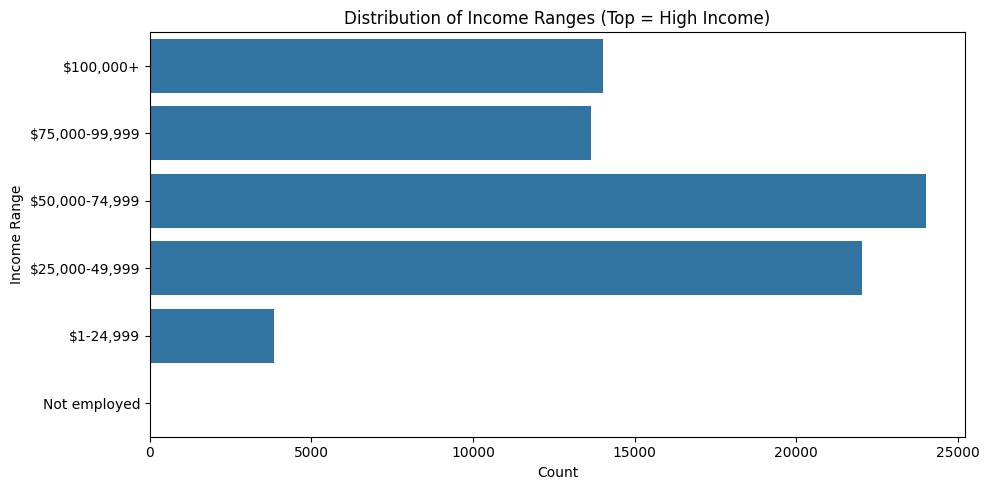

```python
sorted_income_ranges = sorted(unique_ranges, key=income_sort_key, reverse=True)

plt.figure(figsize=(10, 5))
sns.countplot(data=df_clean, y='IncomeRange', order=sorted_income_ranges, color='tab:blue')
plt.title('Distribution of Income Ranges (Top = High Income)')
plt.xlabel('Count')
plt.ylabel('Income Range')
plt.tight_layout()
plt.show()
```

Most borrowers report income between $25,000-49,999 and $50,000-74,999. Very few borrowers reported incomes below $25,000. This is consistent with Prosper targeting relatively credit-worthy individuals.

### Term-Bar Plot : What loan terms are most common?

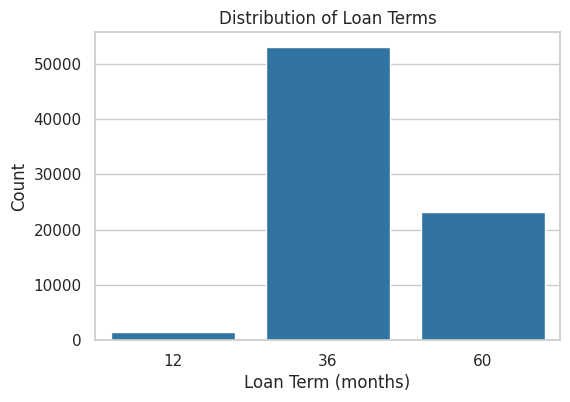

```python
plt.figure(figsize=(6, 4))
sns.countplot(data=df_clean, x='Term', color='tab:blue')
plt.title('Distribution of Loan Terms')
plt.xlabel('Loan Term (months)')
plt.ylabel('Count')
plt.show()
```

Most loans are 36 months long, followed by 60 months. 12-month loans are the least common.

### ProsperRating- Count Plot

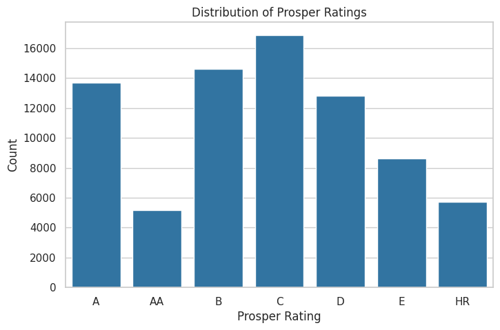

```python
plt.figure(figsize=(8, 5))
order = sorted(df_clean['ProsperRating (Alpha)'].unique())
sns.countplot(data=df_clean, x='ProsperRating (Alpha)', color='tab:blue', order=order)
plt.title('Distribution of Prosper Ratings')
plt.xlabel('Prosper Rating')
plt.ylabel('Count')
plt.show()
```

### StatedMonthlyIncome-Histogram : Distribution of StatedMonthlyIncome

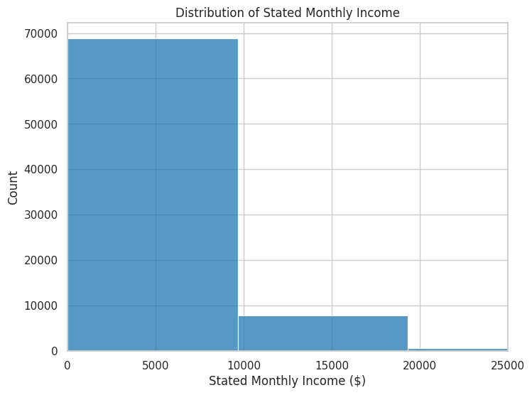

```python
plt.figure(figsize=(8, 6))
sns.histplot(df_clean['StatedMonthlyIncome'], bins=50,color='tab:blue')
plt.xlim(0, 25000)  # limit extreme outliers
plt.title('Distribution of Stated Monthly Income')
plt.xlabel('Stated Monthly Income ($)')
plt.ylabel('Count')
plt.show()
```

Monthly income is heavily right-skewed with some large outliers. The majority of borrowers earn less than $10,000 per month. Consider log transformation for future bivariate or multivariate plots.

### LoanStatus-Count Plot

```python
statuses = df_clean['LoanStatus'].dropna().unique()

def loan_status_rank(status):
    status = status.lower()
    if 'current' in status:
        return 0
    elif 'completed' in status:
        return 1
    elif 'finalpayment' in status:
        return 2
    elif 'past due' in status:
        # Extract day range, "1-15" or ">120"
        import re
        match = re.search(r'(\d+)', status)
        if match:
            return 3 + int(match.group(1))  # rank based on days
        elif '>120' in status:
            return 10_000
        else:
            return 9999
    elif 'charged' in status:
        return 999_999
    elif 'default' in status:
        return 1_000_000
    else:
        return np.inf

sorted_statuses = sorted(statuses, key=loan_status_rank)
```

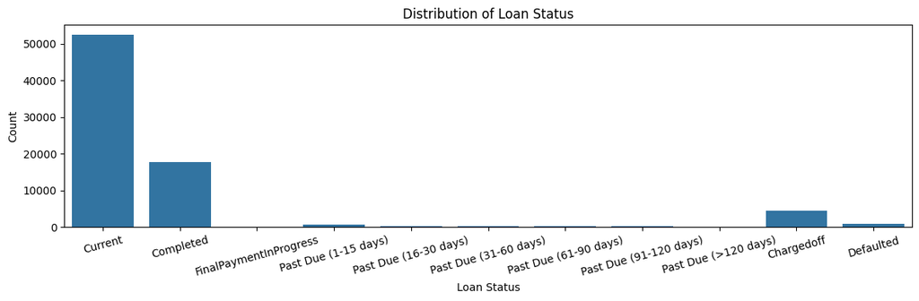

```python
plt.figure(figsize=(12, 4))
sns.countplot(data=df_clean, x='LoanStatus', color='tab:blue', order=sorted_statuses)
plt.title('Distribution of Loan Status')
plt.xticks(rotation=15)
plt.xlabel('Loan Status')
plt.ylabel('Count')
plt.tight_layout()
plt.show()
```

The most common loan status is Current, followed by Completed. There are smaller groups like Chargedoff, Defaulted, which may be useful for analyzing default risk later.

### Of the features you investigated, were there any unusual distributions? Did you perform any operations on the data to tidy, adjust, or change the form of the data? If so, why did you do this?

> Some features like StatedMonthlyIncome were highly skewed due to a few large values. I didn’t remove them, but I limited the axis in plots for better visibility. I also dropped rows with missing values to keep the dataset clean and consistent for analysis.

## Bivariate Exploration

### How does Prosper Rating relate to Borrower APR?

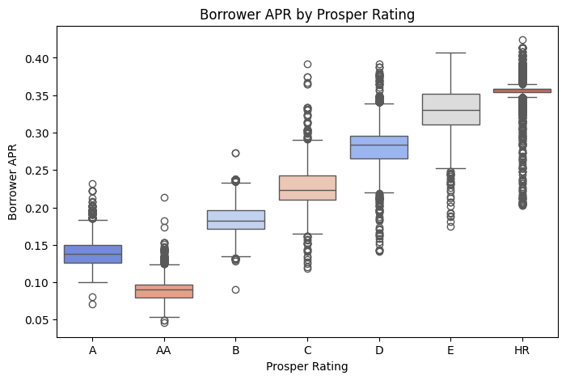

```python
plt.figure(figsize=(8, 5))
order = sorted(df_clean['ProsperRating (Alpha)'].unique())
sns.boxplot(
    data=df_clean,
    x='ProsperRating (Alpha)',
    y='BorrowerAPR',
    order=order,
    hue='ProsperRating (Alpha)',
    palette='coolwarm',
    legend=False
)
plt.title('Borrower APR by Prosper Rating')
plt.xlabel('Prosper Rating')
plt.ylabel('Borrower APR')
plt.show()
```

Borrowers with higher Prosper ratings (like AA, A) tend to have lower APRs, while lower ratings (like HR, E) have much higher APRs. This shows a clear inverse relationship between credit rating and interest rate.

### Does income range affect the APR?

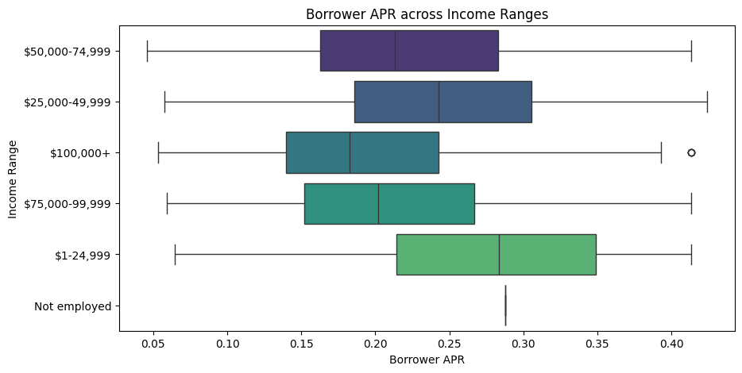

```python
plt.figure(figsize=(10, 5))
order = df_clean['IncomeRange'].value_counts().index
sns.boxplot(
    data=df_clean,
    y='IncomeRange',
    x='BorrowerAPR',
    order=order,
    hue='IncomeRange',      # tie palette to IncomeRange
    palette='viridis',
    legend=False
)
plt.title('Borrower APR across Income Ranges')
plt.xlabel('Borrower APR')
plt.ylabel('Income Range')
plt.show()
```

Borrowers with higher income ranges generally receive lower APRs, while those with lower income ranges tend to have wider and higher APR distributions.

### Does a borrower’s stated monthly income have a noticeable effect on the APR they receive

#### BorrowerAPR vs StatedMonthlyIncome (log scale for income)

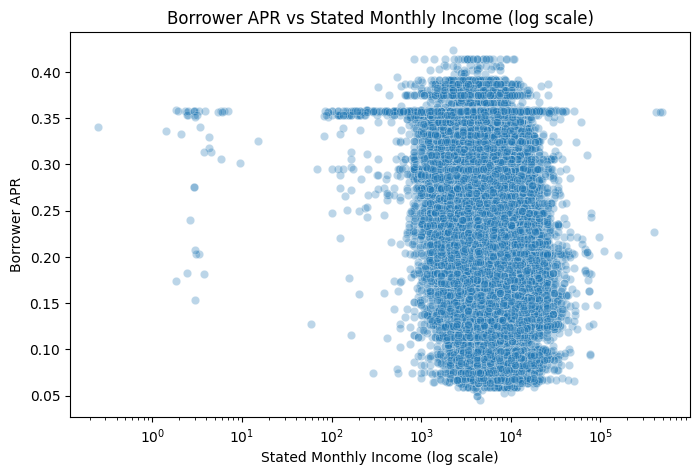

```python
plt.figure(figsize=(8,5))
sns.scatterplot(data=df_clean, x='StatedMonthlyIncome', y='BorrowerAPR', alpha=0.3)
plt.xscale('log')
plt.title('Borrower APR vs Stated Monthly Income (log scale)')
plt.xlabel('Stated Monthly Income (log scale)')
plt.ylabel('Borrower APR')
plt.show()
```

`The scatter plot shows that Borrower APR doesn’t strongly depend on stated monthly income. Many borrowers receive an APR around 0.35, likely due to standard rates or caps. Using a log scale on income helps show the dense middle-income range clearly, while keeping extreme values from stretching the axis.

### Does a higher Debt-to-Income Ratio consistently lead to a higher Borrower APR

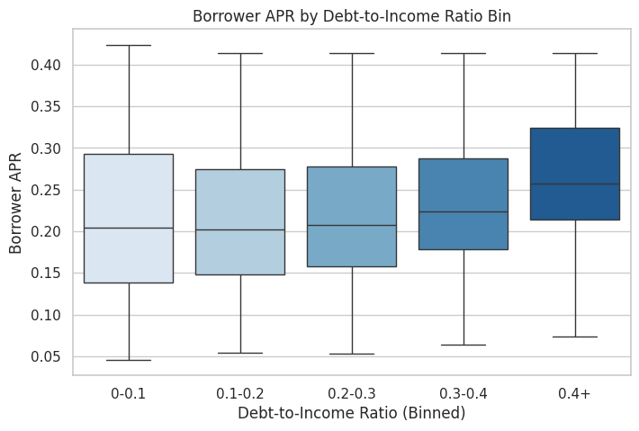

```python
df_clean['DTI_bin'] = pd.cut(df_clean['DebtToIncomeRatio'],
                             bins=[0, 0.1, 0.2, 0.3, 0.4, 1],
                             labels=['0-0.1', '0.1-0.2', '0.2-0.3', '0.3-0.4', '0.4+'])

plt.figure(figsize=(8, 5))
sns.boxplot(data=df_clean, x='DTI_bin', y='BorrowerAPR', hue='DTI_bin', palette='Blues', legend=False)
plt.title('Borrower APR by Debt-to-Income Ratio Bin')
plt.xlabel('Debt-to-Income Ratio (Binned)')
plt.ylabel('Borrower APR')
plt.show()
```

The boxplot indicates that Borrower APR remains relatively consistent across different Debt-to-Income Ratio bins, with only a slight increase in APR for borrowers with higher DTI (0.4+). This suggests weak influence of DTI on APR levels.

### Clustered Bar Chart – Loan Status by Term

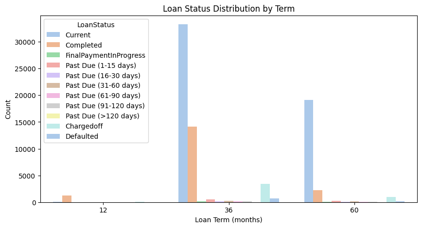

```python
plt.figure(figsize=(10, 5))
sns.countplot(
    data=df_clean,
    x='Term',
    hue='LoanStatus',
    palette='pastel',
    hue_order=sorted_statuses
)

plt.title('Loan Status Distribution by Term')
plt.xlabel('Loan Term (months)')
plt.ylabel('Count')
plt.xticks(rotation=0)
plt.show()
```

### Talk about some of the relationships you observed in this part of the investigation. How did the feature(s) of interest vary with other features in the dataset?

> BorrowerAPR was lower for borrowers with higher Prosper Ratings and Income Ranges. It didn’t change much with Debt-to-Income Ratio or Stated Monthly Income. The clearest pattern was: better credit = lower APR.

## Multivariate Exploration

### Does income and credit rating together affect the Borrower APR?

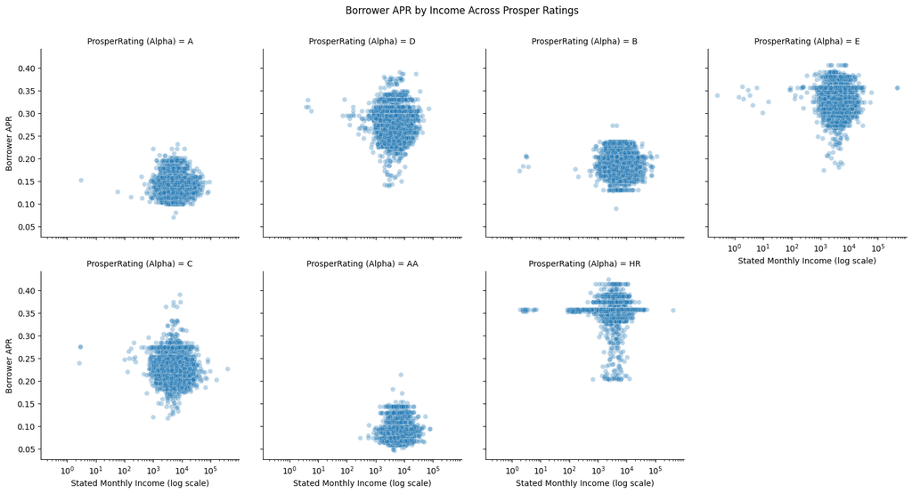

```python
g = sns.FacetGrid(df_clean, col='ProsperRating (Alpha)', col_wrap=4, height=4, sharey=True)
g.map_dataframe(sns.scatterplot, x='StatedMonthlyIncome', y='BorrowerAPR', alpha=0.3)
g.set(xscale='log')
g.set_axis_labels("Stated Monthly Income (log scale)", "Borrower APR")
g.fig.suptitle("Borrower APR by Income Across Prosper Ratings", y=1.05)
plt.show()
```

Even at similar income levels, borrowers with better Prosper Ratings (e.g., AA, A) tend to get lower APRs than those with lower ratings (e.g., E, HR).

### How do Income, Prosper Score, and APR interact together?

```python
bins = [0, 5000, 10000, 15000, 20000, 30000, 40000, 50000]
df_clean['IncomeBin'] = pd.cut(df_clean['StatedMonthlyIncome'], bins=bins)
```

[figure not shown]

```python
bin_order = df_clean['IncomeBin'].cat.categories.astype(str).tolist()

plt.figure(figsize=(12, 6))
sns.stripplot(
    data=df_clean,
    x='IncomeBin_str',
    y='BorrowerAPR',
    hue='ProsperScore',
    dodge=True,
    jitter=0.35,
    palette='viridis',
    alpha=0.3,
    size=2,
    order=bin_order
)
plt.xticks(rotation=45)
plt.title('APR vs. Income Binned and Colored by Prosper Score')
plt.xlabel('Monthly Income Bin')
plt.ylabel('Borrower APR')
plt.legend(bbox_to_anchor=(1.05, 1), loc='upper left', title='Prosper Score')
plt.tight_layout()
plt.show()
```

This scatter plot shows that higher Prosper Scores are associated with lower APRs across different income levels. Even with similar income, borrowers with better scores tend to get better interest rates.

### Talk about some of the relationships you observed in this part of the investigation. Were there features that strengthened each other in terms of looking at your feature(s) of interest?

> Yes, Prosper Score and Prosper Rating both affect Borrower APR. Higher scores and better ratings mean lower APRs. Income also matters, but even with similar incomes, better scores lead to lower APRs. So, these features together help explain APR better.

### Were there any interesting or surprising interactions between features?

> Yes, even borrowers with similar incomes had different APRs depending on their Prosper Score or Rating. This shows that creditworthiness affects APR more than income alone, which was interesting to see.

## Conclusions

> The dataset contains detailed loan and borrower information from Prosper, with 113,937 entries and 81 variables, but many missing values required cleaning.

> The main focus was on Borrower APR, investigating what influences loan interest rates.

> Borrowers with higher credit ratings and scores consistently receive lower APRs, showing a strong inverse relationship between creditworthiness and interest rates.

> Income impacts APR but less strongly than credit ratings; borrowers with similar incomes may still have different APRs depending on their credit scores.

> Debt-to-Income Ratio has a mild effect on APR, with slightly higher APRs for borrowers with very high DTI.

> Multivariate analysis revealed that combining features like Prosper Score, Prosper Rating, and Income gives a better understanding of APR variations than looking at any single feature alone.

> Overall, creditworthiness metrics are the strongest predictors of loan interest rates on the Prosper platform, more so than income or debt alone.